# Project 1

Tina Pai

March 9, 2017

## 0. Intro

The overarching goal of this project is to evaluate how the the amount a patient has to pay (i.e. after Medicare) change for different regions or urban/rural areas of the country.

We will be looking at a dataset from Centers for Medicare and Medicaid Services (https://www.cms.gov/research-statistics-data-and-systems/statistics-trends-and-reports/medicare-provider-charge-data/inpatient.html). Medicare is the US program that assists in covering the costs of health expenses for people who are 65 or older, as well as some younger people with disabilities. The dataset we will be using gives the cumulative charges for procedures billed to Medicare for more than 3,000 U.S. hospitals for Fiscal Year 2011 (Fiscal Year: the 12-month period ending on 30 September of that year, having begun on 1 October of the previous calendar year). The dataset is intended to help Medicare recipients to have a sense of the costs at different institutes or for different procedures (Medicare beneficiaries still will have remaining out-of-pocket costs after the federal government pays its portion).

We will only look at the following diagnoses:

- Chronic Obstructive Pulmonary Disease (COPD) This is an umbrella term used to describe progressive lung diseases, characterized by increasing breathlessness.
- Heart failure
- Hip/Pelvis fractures
- Diabetes

## 1. Data

```r
library(dplyr)
library(ggplot2)
library(plotrix)

#read in data
medicareData <- read.csv("combinedData.csv")

#subset the relevant diagnoses
medicareData <- medicareData %>%
  filter(DRG.Definition %in% c("192 - CHRONIC OBSTRUCTIVE PULMONARY DISEASE W/O CC/MCC",
                               "293 - HEART FAILURE & SHOCK W/O CC/MCC",
                               "536 - FRACTURES OF HIP & PELVIS W/O MCC",
                               "638 - DIABETES W CC"))
medicareData$DRG.Definition <- droplevels(medicareData$DRG.Definition)
levels(medicareData$DRG.Definition) <- c("COPD", "heart failure", "fractures", "diabetes")

#turn Urban into factor with labels
medicareData$Urban <- factor(medicareData$Urban, levels=c(0, 1, 2, 3, 4, 5),
                             labels=c("mixed", "only rural","rural and urban clusters",
                                      "only urban clusters", "urban clusters and urban",
                                      "only urban"))

#make PatientPays and PctPatientPays
medicareData$PatientPays <- medicareData$Average.Total.Payments -
  medicareData$Average.Medicare.Payments
medicareData$PctPatientPays <- medicareData$PatientPays /
  medicareData$Average.Total.Payments

#make urbanByRegions
medicareData$urbanByRegions <- medicareData$Urban:medicareData$regions
medicareData$urbanByRegions <- droplevels(medicareData$urbanByRegions)

summary(medicareData)
```

```
##  Provider.State       DRG.Definition  Provider.Id
##  CA     : 596   COPD         :2593   Min.   : 10001
##  TX     : 592   heart failure:2443   1st Qu.:110186
##  FL     : 519   fractures    :1103   Median :250069
##  NY     : 459   diabetes     :1762   Mean   :257006
##  PA     : 399                        3rd Qu.:390016
##  IL     : 389                        Max.   :670071
##  (Other):4947
##                   Provider.Name       Provider.City  Total.Discharges
##  GOOD SAMARITAN HOSPITAL :  29   CHICAGO     :  81   Min.   : 11.00
##  MERCY MEDICAL CENTER    :  20   BALTIMORE   :  42   1st Qu.: 17.00
##  ST JOSEPH HOSPITAL      :  20   BROOKLYN    :  41   Median : 25.00
##  ST JOSEPH MEDICAL CENTER:  20   HOUSTON     :  41   Mean   : 33.47
##  MERCY HOSPITAL          :  19   PHILADELPHIA:  40   3rd Qu.: 41.00
##  ST FRANCIS HOSPITAL     :  15   SPRINGFIELD :  37   Max.   :326.00
##  (Other)                 :7778   (Other)     :7619
##  Average.Covered.Charges Average.Total.Payments Average.Medicare.Payments
##  Min.   :  3134          Min.   : 3144          Min.   : 2182
##  1st Qu.: 11352          1st Qu.: 4212          1st Qu.: 3255
##  Median : 15544          Median : 4711          Median : 3723
##  Mean   : 18368          Mean   : 5072          Mean   : 4093
##  3rd Qu.: 22070          3rd Qu.: 5532          3rd Qu.: 4517
##  Max.   :130690          Max.   :19512          Max.   :18613
##
##  Provider.Zip.Code      regions                          Urban
##  Min.   : 1040     midwest  :1842   mixed                   :2948
##  1st Qu.:27565     northeast:1469   only rural              : 104
##  Median :44112     south    :3357   rural and urban clusters:1827
##  Mean   :47812     west     :1233   only urban clusters     :   6
##  3rd Qu.:72342                      urban clusters and urban:   0
##  Max.   :99701                      only urban              :2520
##                                     NA's                    : 496
##   PatientPays      PctPatientPays                           urbanByRegions
##  Min.   :  261.2   Min.   :0.03898   mixed:south                   :1239
##  1st Qu.:  770.2   1st Qu.:0.15297   rural and urban clusters:south:1010
##  Median :  898.4   Median :0.19230   only urban:south              : 784
##  Mean   :  979.3   Mean   :0.19949   mixed:midwest                 : 663
##  3rd Qu.: 1059.3   3rd Qu.:0.23569   only urban:northeast          : 625
##  Max.   :10676.8   Max.   :0.74215   (Other)                       :3084
##                                      NA's                          : 496
```

## 2. Basic Summaries

```r
#basic summaries of PatientPays and PctPatientPays
summary(medicareData$PatientPays)
```

```
##    Min. 1st Qu.  Median    Mean 3rd Qu.    Max.
##   261.2   770.2   898.4   979.3  1059.0 10680.0
```

```r
summary(medicareData$PctPatientPays)
```

```
##    Min. 1st Qu.  Median    Mean 3rd Qu.    Max.
## 0.03898 0.15300 0.19230 0.19950 0.23570 0.74210
```

```r
diagnoses <- c("COPD", "heart failure", "fractures", "diabetes")
for(disease in diagnoses){
  print(disease)
  print(summary(medicareData$PatientPays[medicareData$DRG.Definition==disease]))
  print(summary(medicareData$PctPatientPays[medicareData$DRG.Definition==disease]))
}
```

```
## [1] "COPD"
##    Min. 1st Qu.  Median    Mean 3rd Qu.    Max.
##   372.0   847.2   963.4  1064.0  1163.0  5701.0
##    Min. 1st Qu.  Median    Mean 3rd Qu.    Max.
## 0.05606 0.17480 0.21200 0.21950 0.25620 0.64150
## [1] "heart failure"
##    Min. 1st Qu.  Median    Mean 3rd Qu.    Max.
##   261.2   694.3   793.8   854.1   926.8  7009.0
##    Min. 1st Qu.  Median    Mean 3rd Qu.    Max.
## 0.03898 0.14970 0.18160 0.18690 0.21520 0.66970
## [1] "fractures"
##    Min. 1st Qu.  Median    Mean 3rd Qu.    Max.
##   508.7   890.3   965.7  1027.0  1058.0  3694.0
##    Min. 1st Qu.  Median    Mean 3rd Qu.    Max.
## 0.07703 0.18340 0.21930 0.22060 0.24740 0.53620
## [1] "diabetes"
##    Min. 1st Qu.  Median    Mean 3rd Qu.    Max.
##   268.0   724.3   859.6   997.4  1079.0 10680.0
##    Min. 1st Qu.  Median    Mean 3rd Qu.    Max.
## 0.04187 0.12280 0.15940 0.17420 0.20420 0.74210
```

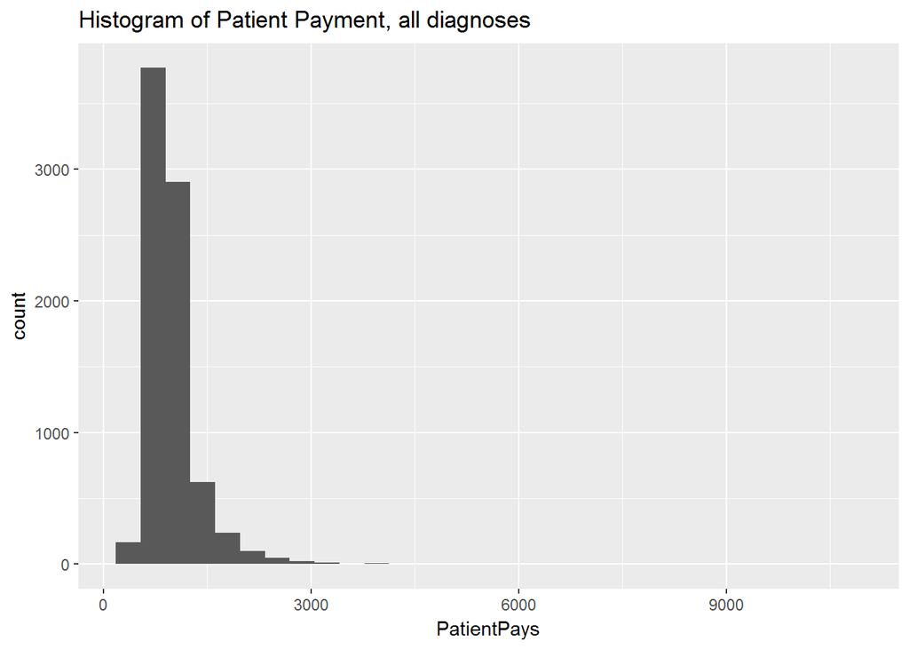

```r
#Histograms of PatientPays and PctPatientPays
ggplot(medicareData, aes(PatientPays)) +
  geom_histogram() +
      labs(title="Histogram of Patient Payment, all diagnoses")
```

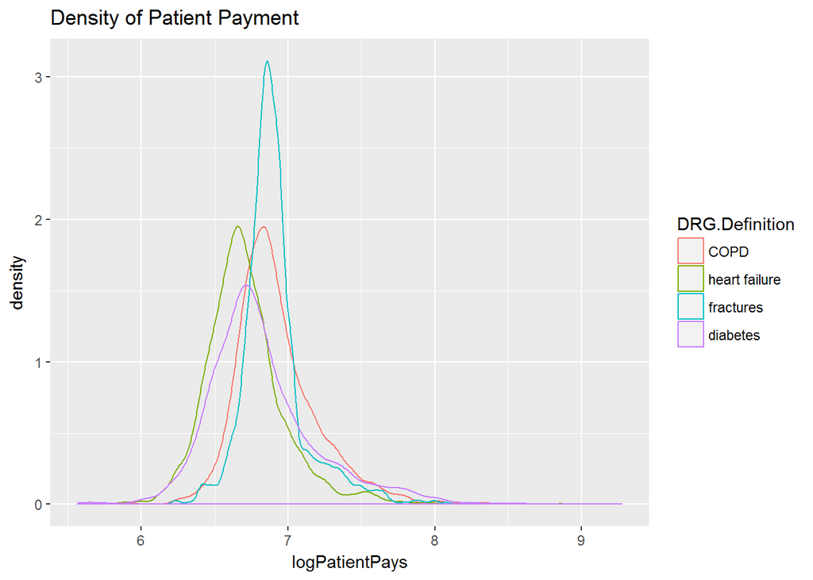

```r
#log-transform pay data
medicareData <- medicareData %>%
  mutate(logPatientPays = log(PatientPays)) %>%
  mutate(logPctPatientPays = log(PctPatientPays))

#Plot densities of log-transformed payments, by diagnosis
ggplot(medicareData, aes(logPatientPays, col=DRG.Definition)) +
  geom_density() +
  labs(title="Density of Patient Payment")
```

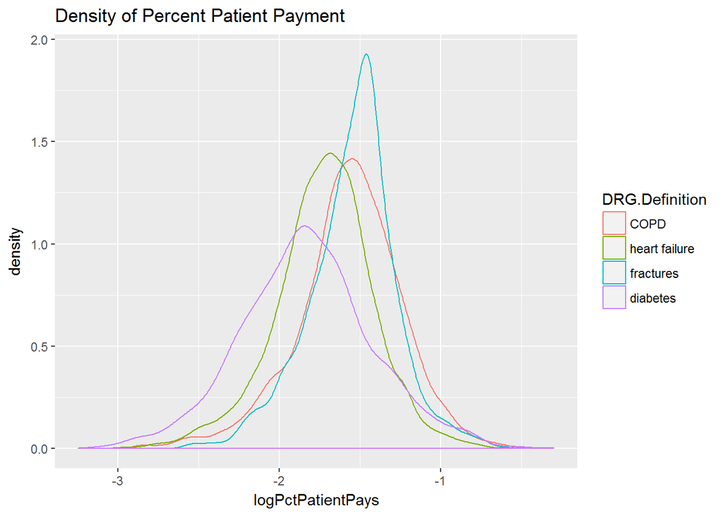

```r
ggplot(medicareData, aes(logPctPatientPays, col=DRG.Definition)) +
  geom_density() +
  labs(title="Density of Percent Patient Payment")
```

```r
#Cross-tabulation of Urban and regions
table(medicareData$Urban, medicareData$regions)
```

```
##
##                            midwest northeast south west
##   mixed                        663       535  1239  511
##   only rural                    13        13    75    3
##   rural and urban clusters     464       199  1010  154
##   only urban clusters            0         2     4    0
##   urban clusters and urban       0         0     0    0
##   only urban                   612       625   784  499
```

**Summaries**

In order of the median cost that patients pay, the cost of treatments rank as fractures (median 965) > COPD (median 963) > diabetes (median 859) > heart failure (median 793). However, fractures and COPD are close in their measures of central tendency; if you use the means instead, COPD patients pay more (1064) than fracture patients (1027).

The percentage that people pay for their treatments ordered from high to low is fractures (21.9%) > COPD (21.2%) > heart failure (18.1%) > diabetes (15.9%).

**Plots**

**Cross-tabulation**

In the cross-tabulation of Urban and regions, I can see that the data is very unbalanced. We have 1239 mixed areas in the south, and 0 areas with both urban clusters and urban places. There are very few observations in “only rural” and “only urban clusters”, and there are none in “urban clusters and urban”. This means that our `urbanByRegions` variable is going to be missing observations in those locations.

## 3. Distributions

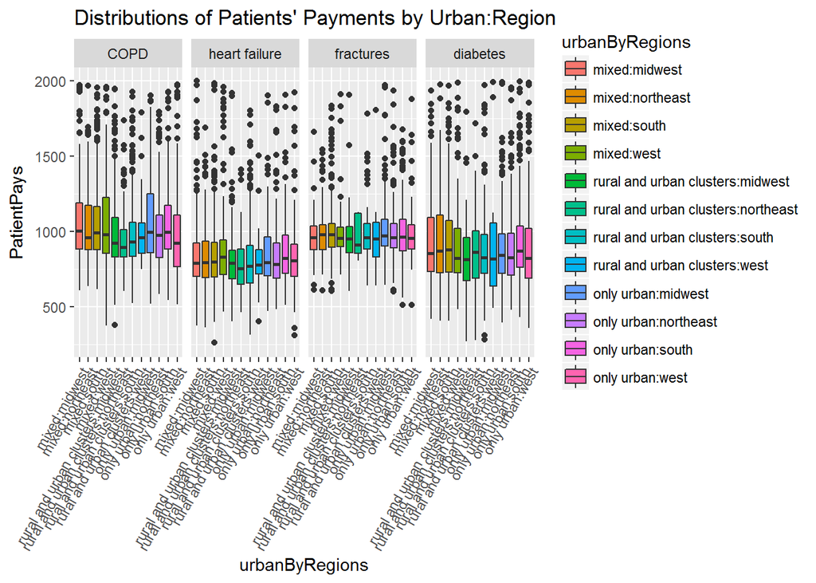

```r
#Keep only urbanByRegions with Urban values 0, 2, and 5
medicareData <- medicareData %>%
  filter(Urban %in% c("mixed", "rural and urban clusters", "only urban")) %>%
  mutate(urbanByRegions = Urban:regions)
medicareData$urbanByRegions <- droplevels(medicareData$urbanByRegions)

#plot boxplots for patientpays grouped by urbanbyregions
ggplot(medicareData, aes(urbanByRegions, PatientPays, fill=urbanByRegions)) +
  geom_boxplot() +
  labs(title="Distributions of Patients' Payments by Urban:Region") +
  theme(axis.text.x = element_text(angle = 60, hjust = 1)) +
  ylim(c(250, 2000)) +
  facet_grid(.~DRG.Definition)
```

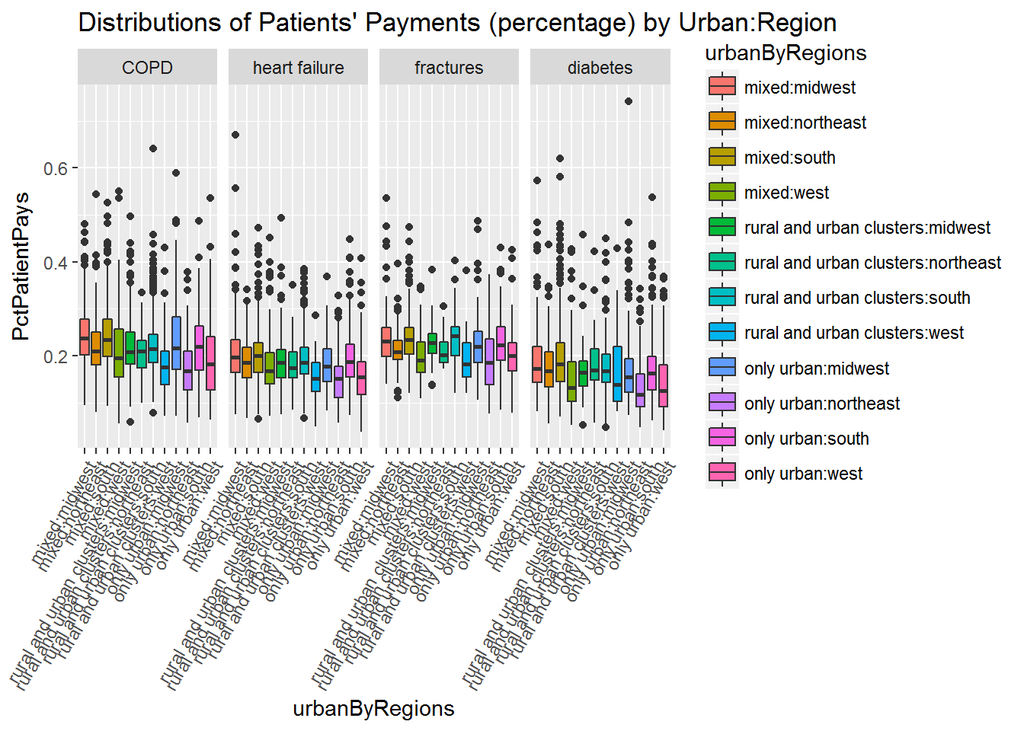

```r
#plot boxplots for pctpatientpays
ggplot(medicareData, aes(urbanByRegions, PctPatientPays, fill=urbanByRegions)) +
  geom_boxplot() +
  labs(title="Distributions of Patients' Payments (percentage) by Urban:Region") +
  theme(axis.text.x = element_text(angle = 60, hjust = 1)) +
  facet_grid(.~DRG.Definition)
```

**Boxplots**

Some questions of interest that I would ask the graphs are that I want to know whether people pay different percentages of their healthcare if they live in different regions, and I also want to know if the treatments for a disease would also cost different amounts across regions.

I’m plotting boxplots of the distributions of payment, grouped by `urbanByRegions`. It doesn’t show any particularly obvious patterns.

What I can tell is that the areas of “rural and urban clusters” in the northeast region pay the least for their healthcare, though they pay for a relatively high percentage of their treatments. It also looks like the only-urban northeast, only-urban west, rural urban clusters west, and mixed west regions pay the least in percentage of their healthcare. I suppose that could mean that western states tend to cover more of people’s healthcare, if it’s a significant difference. We’ll find this out in the next section.

## 4. Inference

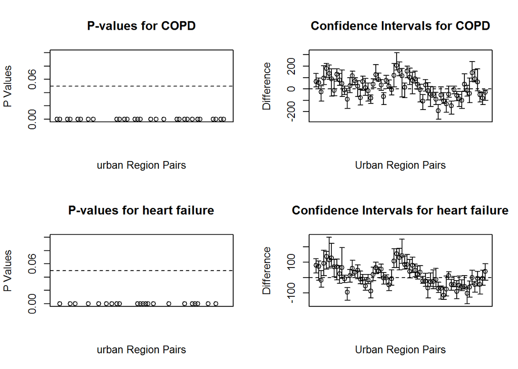

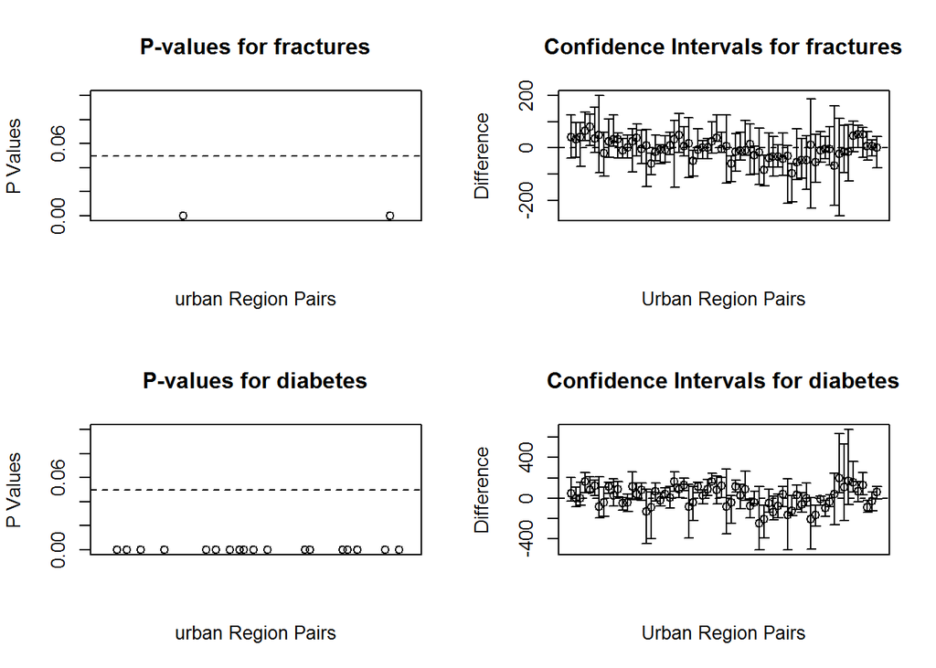

```r
#functions for doing permutation and bootstrap
permutation.test <- function(group1,group2, FUN, repetitions){
  makePermutedStats<-function(){
      sampled <- sample(1:length(c(group1,group2)), size=length(group1),replace=FALSE)
      return(FUN(c(group1,group2)[sampled], c(group1,group2)[-sampled]))
  }
  stat.obs <- FUN(group1,  group2)
  stat.permute <-replicate(repetitions,makePermutedStats())
  p.value <- sum(stat.permute >= stat.obs) / repetitions
  return(list(p.value=p.value,observedStat=stat.obs,permutedStats=stat.permute))
}

getDiff <- function(data, payment, location1, location2) {
  v1 <- data[[payment]][data$urbanByRegions==location1]
  v2 <- data[[payment]][data$urbanByRegions==location2]
  diffInMeans <- mean(v1) - mean(v2)
  return(diffInMeans)
}
doBoot <- function(data, statistic, r, payment, location1, location2, confLevel=.95) {
  observedStat <- statistic(data, payment, location1, location2)
  getNewStat <- function(){
      indices <- sample(x=1:nrow(data), size=nrow(data), replace = T)
      newDF <- data[indices,]
    return(statistic(newDF, payment, location1, location2))
  }
  level=1-confLevel
  bootStats<- replicate(r, getNewStat())
  upper <- quantile(bootStats, level)
  lower <- quantile(bootStats, confLevel)
  return(list(lower=lower,estimate=observedStat,upper=upper))
}

p <- c()
ci.lower <- c()
ci.upper <- c()
ci.est <- c()
drg <- c()

pPct <- c()
ci.lowerPct <- c()
ci.upperPct <- c()
ci.estPct <- c()
drgPct <- c()

ur1 <- c()
ur2 <- c()

#The tests
urbanRegionPairs <- combn(levels(medicareData$urbanByRegions), 2)
numPairs <- ncol(urbanRegionPairs)
for(i in 1:numPairs) {
  dfRegion1 <- medicareData %>%
    filter(urbanByRegions == urbanRegionPairs[1, i])
  dfRegion2 <-medicareData %>%
    filter(urbanByRegions == urbanRegionPairs[2, i])

  for(diagnosis in diagnoses) {
    ur1 <- c(ur1, urbanRegionPairs[1, i])
    ur2 <- c(ur2, urbanRegionPairs[2, i])
    #PatientPays hypothesis testing
    drg <- c(drg, diagnosis)
    v1 <- dfRegion1$PatientPays[dfRegion1$DRG.Definition==diagnosis]
    v2 <- dfRegion2$PatientPays[dfRegion2$DRG.Definition==diagnosis]
    ptest <- permutation.test(v1, v2, FUN=function(x,y){abs(mean(x)-mean(y))}, 10)
    p <- c(p, ptest$p.value)

    #PatientPays confidence intervals, bonferroni corrected
    ci <- doBoot(medicareData[medicareData$DRG.Definition==diagnosis,],
                 statistic=getDiff,
                 r=10,
                 payment="PatientPays",
                 location1=urbanRegionPairs[1, i],
                 location2=urbanRegionPairs[2, i],
                 confLevel = .95/numPairs)
    ci.lower <- c(ci.lower, ci$lower)
    ci.upper <- c(ci.upper, ci$upper)
    ci.est <- c(ci.est, ci$estimate)


    #PctPatientPays hypothesis testing
    drgPct <- c(drgPct, diagnosis)
    v1Pct <- dfRegion1$PctPatientPays[dfRegion1$DRG.Definition==diagnosis]
    v2Pct <- dfRegion2$PctPatientPays[dfRegion2$DRG.Definition==diagnosis]
    ptestPct <- permutation.test(v1Pct, v2Pct, FUN=function(x,y){abs(mean(x)-mean(y))}, 10)
    pPct <- c(pPct, ptestPct$p.value)

    #PctPatientPays confidence intervals, bonferroni corrected
    ciPct <- doBoot(medicareData[medicareData$DRG.Definition==diagnosis,],
                    statistic=getDiff,
                    r=10,
                    payment="PctPatientPays",
                    location1=urbanRegionPairs[1, i],
                    location2=urbanRegionPairs[2, i],
                    confLevel = .95/numPairs)
    ci.lowerPct <- c(ci.lowerPct, ciPct$lower)
    ci.upperPct <- c(ci.upperPct, ciPct$upper)
    ci.estPct <- c(ci.estPct, ciPct$estimate)
  }
}

#bonferroni correction of p-values
p <- p*numPairs
pPct <- pPct*numPairs

resultsDF <- data.frame(drg, p, ci.lower, ci.upper, ci.est, ur1, ur2)
resultsDFPct <- data.frame(drgPct, pPct, ci.lowerPct, ci.upperPct, ci.estPct, ur1, ur2)

#PatientPays plots
par(mfrow=c(2,2))
for(diagnosis in diagnoses){
  #Plot p-values
  plot(resultsDF$p[resultsDF$drg==diagnosis],
       ylim=c(0, .1),
       main=paste("P-values for", diagnosis),
       xlab="urban Region Pairs",
       ylab="P Values",
       xaxt="n")
  abline(h=.05, lty=2)

  #Plot Confidence Intervals
  plotCI(x=1:nrow(resultsDF[resultsDF$drg==diagnosis,]),
         resultsDF$ci.est[resultsDF$drg==diagnosis],
         ui=resultsDF$ci.upper[resultsDF$drg==diagnosis],
         li=resultsDF$ci.lower[resultsDF$drg==diagnosis],
         main=paste("Confidence Intervals for", diagnosis),
         xlab="Urban Region Pairs", ylab="Difference", xaxt="n")
  abline(h = 0, lty = 2)
}
```

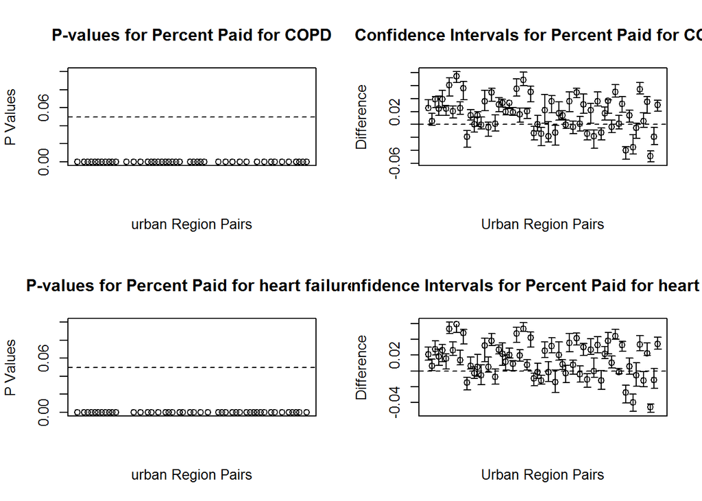

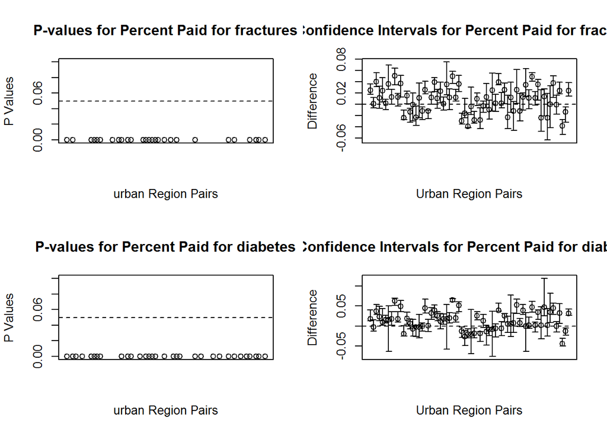

```r
#PctPatientPays plots
for(diagnosis in diagnoses){
  #Plot p-values
  plot(resultsDFPct$pPct[resultsDFPct$drgPct==diagnosis],
       ylim=c(0, .1), main=paste("P-values for Percent Paid for", diagnosis),
       xlab="urban Region Pairs", ylab="P Values", xaxt="n")
  abline(h=.05, lty=2)

  #Plot Confidence Intervals
  plotCI(x=1:nrow(resultsDFPct[resultsDFPct$drgPct==diagnosis,]),
         resultsDFPct$ci.estPct[resultsDFPct$drgPct==diagnosis],
         ui=resultsDFPct$ci.upperPct[resultsDFPct$drgPct==diagnosis],
         li=resultsDFPct$ci.lowerPct[resultsDFPct$drgPct==diagnosis],
         main=paste("Confidence Intervals for Percent Paid for", diagnosis),
         xlab="Urban Region Pairs", ylab="Difference", xaxt="n")
  abline(h = 0, lty = 2)
}
```

```r
significant <- resultsDF %>%
  filter(p < .05)
significantPct <- resultsDFPct %>%
  filter(pPct < .05)
print(head(significant))
```

```
##             drg p    ci.lower  ci.upper    ci.est           ur1
## 1          COPD 0  17.8331361 136.30315  65.54476 mixed:midwest
## 2          COPD 0   0.6589754  95.47124  54.53675 mixed:midwest
## 3 heart failure 0 -17.8612817 106.82652  71.88078 mixed:midwest
## 4      diabetes 0  54.8944238 253.21985 162.74190 mixed:midwest
## 5          COPD 0 100.7116768 224.45068 181.36691 mixed:midwest
## 6          COPD 0  85.9814497 211.49752 135.67732 mixed:midwest
##                                  ur2
## 1                    mixed:northeast
## 2                        mixed:south
## 3                        mixed:south
## 4   rural and urban clusters:midwest
## 5 rural and urban clusters:northeast
## 6     rural and urban clusters:south
```

```r
print(head(significantPct))
```

```
##          drgPct pPct ci.lowerPct ci.upperPct  ci.estPct           ur1
## 1          COPD    0  0.02603801  0.03807722 0.02492670 mixed:midwest
## 2 heart failure    0  0.01363881  0.03032865 0.02106090 mixed:midwest
## 3     fractures    0  0.01790354  0.03578265 0.02497417 mixed:midwest
## 4      diabetes    0  0.01298619  0.03969645 0.01751108 mixed:midwest
## 5          COPD    0  0.02567222  0.04286177 0.03859021 mixed:midwest
## 6 heart failure    0  0.02012710  0.03827378 0.02771058 mixed:midwest
##               ur2
## 1 mixed:northeast
## 2 mixed:northeast
## 3 mixed:northeast
## 4 mixed:northeast
## 5      mixed:west
## 6      mixed:west
```

**Hypothesis Testing**

Is there a significant difference between the price paid in urban western regions vs price paid in urban northeastern regions? What about each of the other pairs of regions?

I would do hypothesis testing for all the pairs. I’ll use their difference in means as a statistic to see if there’s a difference. Since the distribution of the data is non-normal, I’ll use a permutation test instead of a parametric test.

- My null hypothesis: The difference in means between the two areas is 0.
- Alternative hypothesis: The difference in means is > 0.

So, for each pair of `urbanbyregions`, I can see if there’s a significant difference between their means. I would keep all the p-value results from my tests and check out at the end which pairs have a significant difference. But it’s possible that they were counted significant just by chance, so I’ll do a bonferroni correction to adjust my p-values for good measure.

**Confidence Intervals**

What do I estimate the actual difference is? I’ll find a confidence interval for the difference in payment between the two places. Since the data is very skewed, I shouldn’t use a parametric t-test. Instead, I’ll use a bootstrap confidence interval.

**Significance**